# Bayesian hierarchical models for space-temporal modeling of COVID-19 in Catalonia. Vaccination analysis

### 2.3.1 SIR by week

First, let’s illustrate the differences in the cumulative full vaccination percentages in all the period between hospitalization hot/cold spots estimated by the raw model.

Figure 29: Difference on the vaccination rates between hot/mild/cold spots given by the residual spatial effect of the raw model on hospitalizations

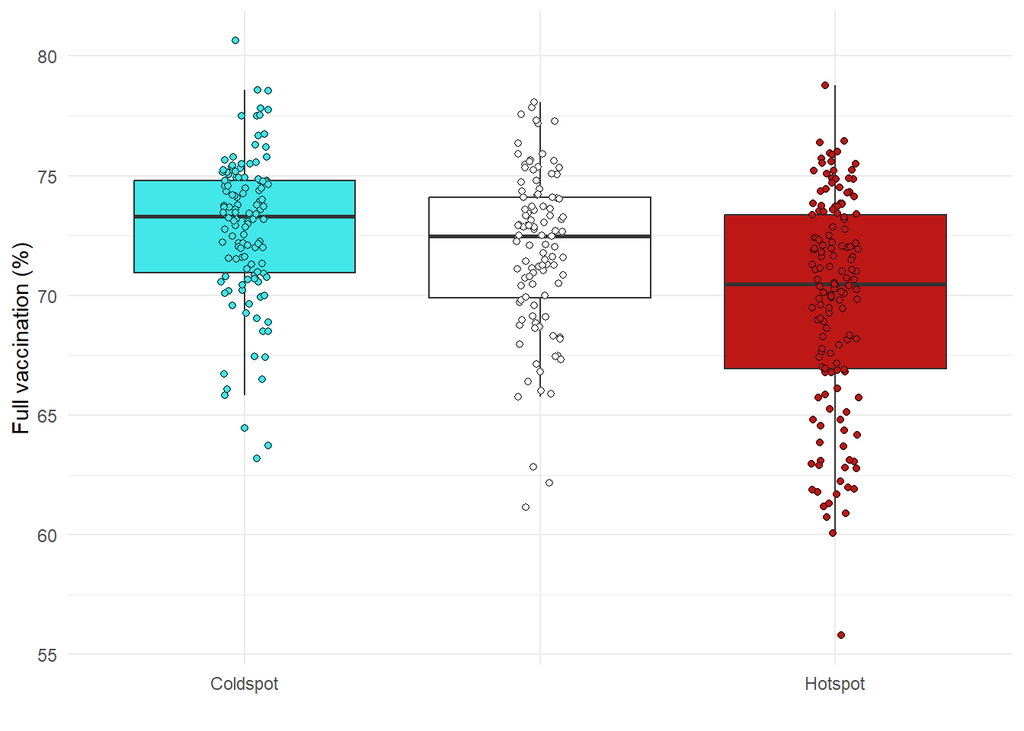

Hot spots have lower full vaccination percentages than cold spots, so we might think that the vaccination could explain some of the spatial effect.

Figure 30: Difference on the vaccination rates between hot/mild/cold spots given by the residual spatial effect of the raw model on cases

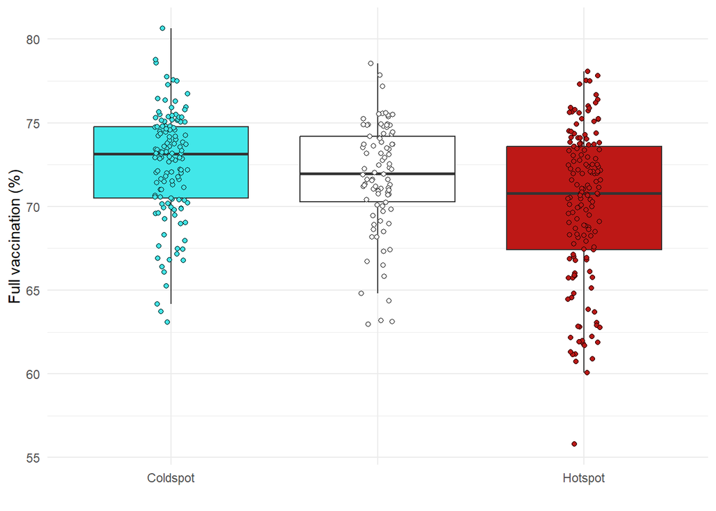

Let’s show the differences on the cumulative full vaccination percentage of the previous week between the estimated hot/cold spots of the actual week, for all the weeks of the study period.

Figure 31: Difference on the vaccination rates between hot/cold spots given by the residual spatio-temporal effect of the raw model on hospitalizations

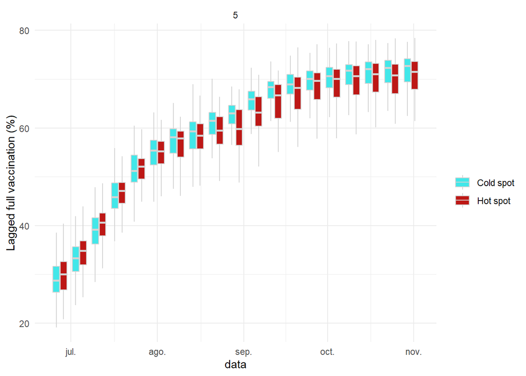

In the beginning there are no differences but after august spatio-temporal hot spots have lower values of vaccination.

Figure 32: Difference on the vaccination rates between hot/cold spots given by the posterior RR effect of the raw model on hospitalizations

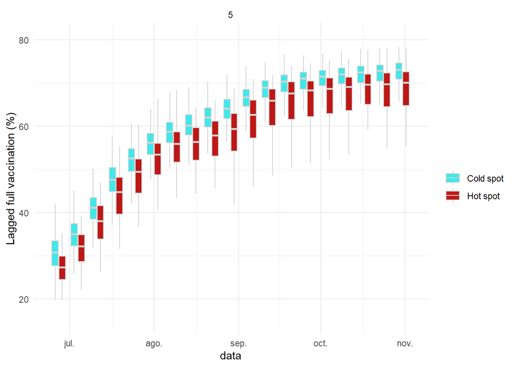

Hot spots have systematically lower cumulated values of full vaccination percentages than cold spots.

Let’s explore the linearity of the relationships between the cumulative vaccination at the end of the studied period and the estimated spatial RR by the raw model.

Figure 33: Plot of the estimated spatial RR of the raw model on cases for each ABS in function of the fully vaccination that we will include in the model

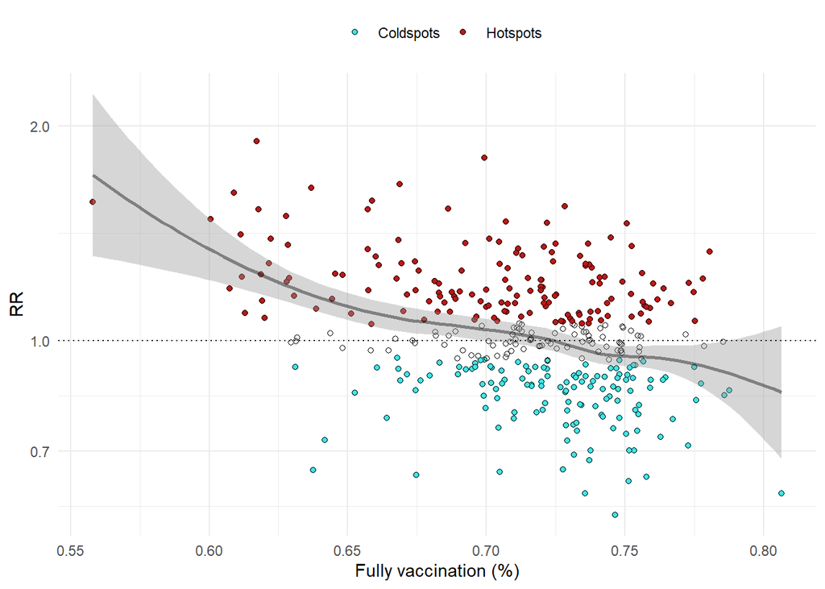

Figure 34: Plot of the estimated spatial RR of the raw model on hospitalisations for each ABS in function of the fully vaccination that we will include in the model

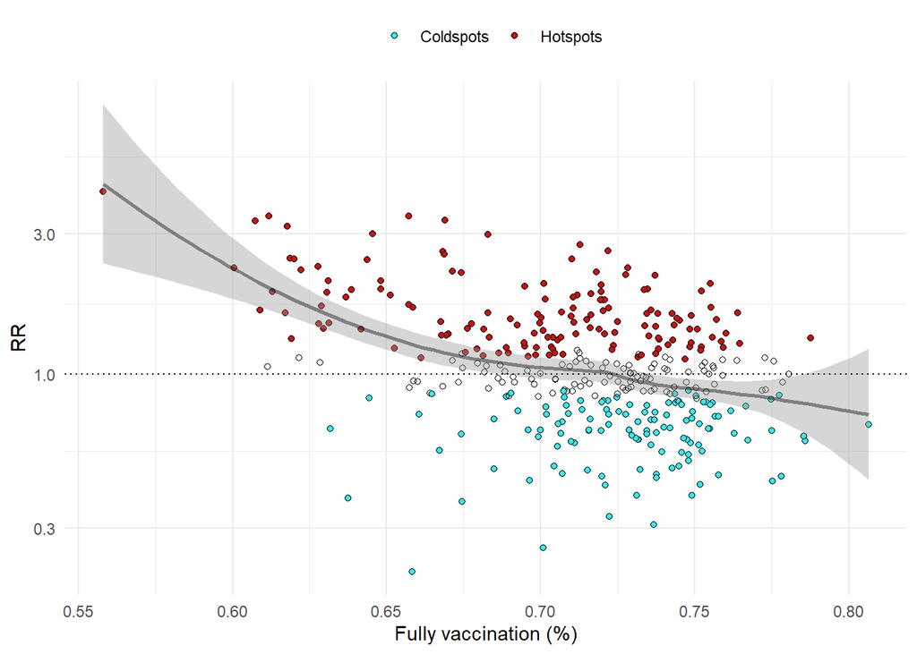

Table 27: Description of estimated DIC and WAIC for all the models

|  | Cases DIC | Cases WAIC | Hospitalization DIC | Hospitalization WAIC |
| --- | --- | --- | --- | --- |
| Raw | 44329.84 | 44490.43 | 21260.10 | 20913.44 |
| Vaccination |  |  | 21270.14 | 20935.24 |
| Vaccination + Covariates | 44317.30 | 44492.73 | 21269.19 | 20933.37 |
| Vaccination (2-week lag) | 44310.13 | 44480.06 | 21265.66 | 20927.00 |

Adjusted models perform better than the raw model in the cases outcome. For the hospitalization outcome, adjusting doesn’t improve the model.

Table 28: Estimated fixed effects and hyperparameters for each model on the cases outcome

|  | Raw | Vaccination + Covariates | Vaccination (2-week lag) |
| --- | --- | --- | --- |
| **Fixed effects** |  |  |  |
| (Intercept) | 0.89 (0.87, 0.91) | 0.87 (0.84, 0.9) | 0.87 (0.84, 0.9) |
| Urban vs Rural |  | 1.04 (0.98, 1.1) | 1.04 (0.98, 1.11) |
| Socioeconomic Index (SI) |  | 1 (0.98, 1.03) | 1.01 (0.99, 1.04) |
| Full vaccination (1-week lag) |  | 0.88 (0.82, 0.95) |  |
| Full vaccination (2-week lag) |  |  | 0.93 (0.86, 0.97) |
| **Random effects** |  |  |  |
| SD (idarea) | 0.21 (0.22, 0.19) | 0.2 (0.22, 0.18) | 0.21 (0.24, 0.18) |
| Phi for idarea | 0.1 (0.05, 0.2) | 0.47 (0.31, 0.65) | 0.47 (0.1, 0.77) |
| SD (idtime) | 0.05 (0.07, 0.03) | 0.05 (0.25, 0.03) | 0.06 (0.1, 0.04) |
| SD (idareatime) | 0.29 (0.3, 0.28) | 0.29 (0.3, 0.28) | 0.29 (0.3, 0.28) |

The role of the structural spatial effect increases.

Table 29: Percentage of explained variability by the spatial, temporal and spatio-temporal patterns of every model on the cases outcome

|  | Variance Spatial (%) | Variance Temporal (%) | Variance Spatio-Temporal (%) |
| --- | --- | --- | --- |
| Raw | 32.92 | 1.84 | 65.24 |
| Vaccination + Covariates | 28.09 | 7.76 | 64.14 |
| Vaccination (2-week lag) | 30.99 | 3.42 | 65.59 |

The spatial variance decreases in favour of the temporal.

Table 30: Estimated fixed effects and hyperparameters for each model on the hospitalization outcome

|  | Raw | Vaccination | Vaccination + Covariates | Vaccination (2-week lag) |
| --- | --- | --- | --- | --- |
| **Fixed effects** |  |  |  |  |
| (Intercept) | 0.81 (0.78, 0.85) | 0.81 (0.78, 0.84) | 0.75 (0.69, 0.81) | 0.74 (0.69, 0.8) |
| Full vaccination (1-week lag) |  | 0.58 (0.5, 0.68) | 0.83 (0.68, 0.98) |  |
| Urban vs Rural |  |  | 1.19 (1.05, 1.36) | 1.21 (1.05, 1.38) |
| Socioeconomic Index (SI) |  |  | 1.2 (1.13, 1.28) | 1.23 (1.17, 1.3) |
| Full vaccination (2-week lag) |  |  |  | 0.97 (0.92, 1.01) |
| **Random effects** |  |  |  |  |
| SD (idarea) | 0.53 (0.61, 0.47) | 0.44 (0.5, 0.39) | 0.41 (0.46, 0.37) | 0.43 (0.48, 0.38) |
| Phi for idarea | 0.66 (0.43, 0.86) | 0.45 (0.22, 0.69) | 0.37 (0.14, 0.62) | 0.44 (0.18, 0.75) |
| SD (idtime) | 0.01 (0.03, 0) | 0.14 (0.22, 0.09) | 0.04 (0.09, 0.02) | 0.02 (0.04, 0.01) |
| SD (idareatime) | 0.23 (0.24, 0.21) | 0.23 (0.24, 0.21) | 0.23 (0.24, 0.21) | 0.23 (0.24, 0.21) |

Vaccination has a high protective effect (42%) and the effect is still high when adjusted by covariates (17%). Considering 2-week lags the effect is small at limit of significance.

The role of the structural effect decreases when adjusted by covariates.

Table 31: Percentage of explained variability by the spatial, temporal and spatio-temporal patterns of every model on the hospitalization outcome

|  | Variance Spatial (%) | Variance Temporal (%) | Variance Spatio-Temporal (%) |
| --- | --- | --- | --- |
| Raw | 84.52 | 0.06 | 15.42 |
| Vaccination | 72.49 | 8.30 | 19.22 |
| Vaccination + Covariates | 75.69 | 1.53 | 22.77 |
| Vaccination (2-week lag) | 78.20 | 0.17 | 21.62 |

The spatial variance decreases in benefit of the temporal and spatio-temporal variance. variance increases when adjusting only by the vaccination in detriment of the spatial variance.

### 2.3.2 SIR whole period

First, let’s illustrate the differences in the cumulative full vaccination percentages in all the period between hospitalization hot/cold spots estimated by the raw model.

Figure 40: Difference on the vaccination rates between hot/mild/cold spots given by the residual spatial effect of the raw model on hospitalizations

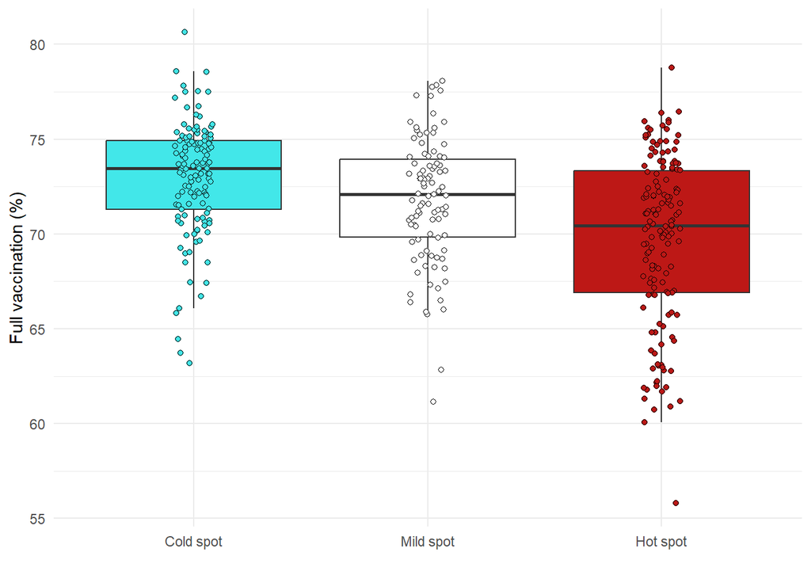

Hot spots have lower full vaccination percentages than cold spots, so we might think that the vaccination could explain some of the spatial effect.

Let’s show the differences on the cumulative full vaccination percentage of the previous week between the estimated hot/cold spots of the actual week, for all the weeks of the study period.

Figure 41: Difference on the vaccination rates between hot/cold spots given by the residual spatio-temporal effect of the raw model on hospitalizations

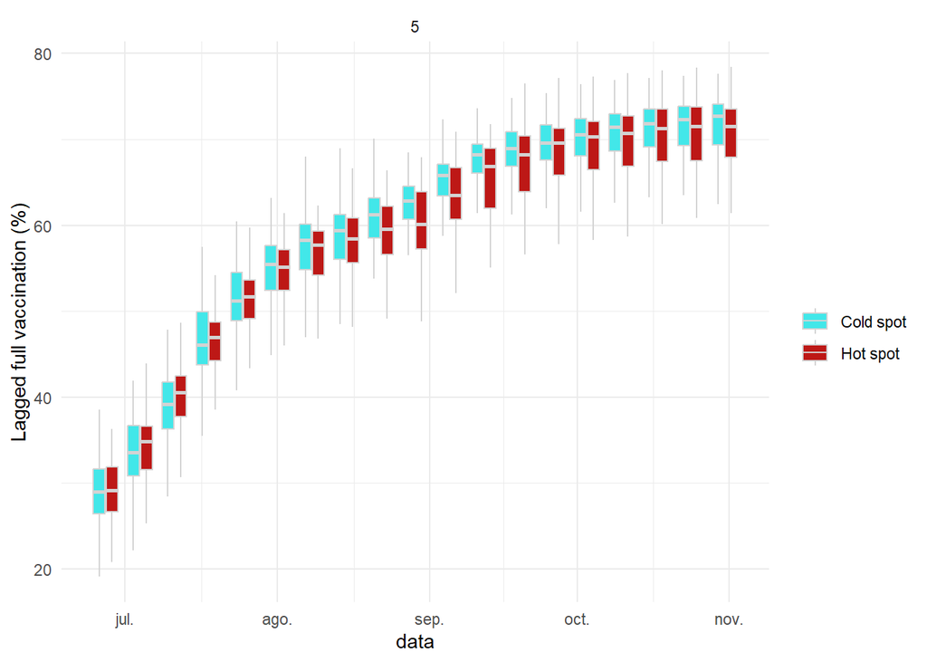

In the beginning there are no differences but after august spatio-temporal hot spots have slightly lower values of vaccination.

Figure 42: Difference on the vaccination rates between hot/cold spots given by the posterior RR effect of the raw model on hospitalizations

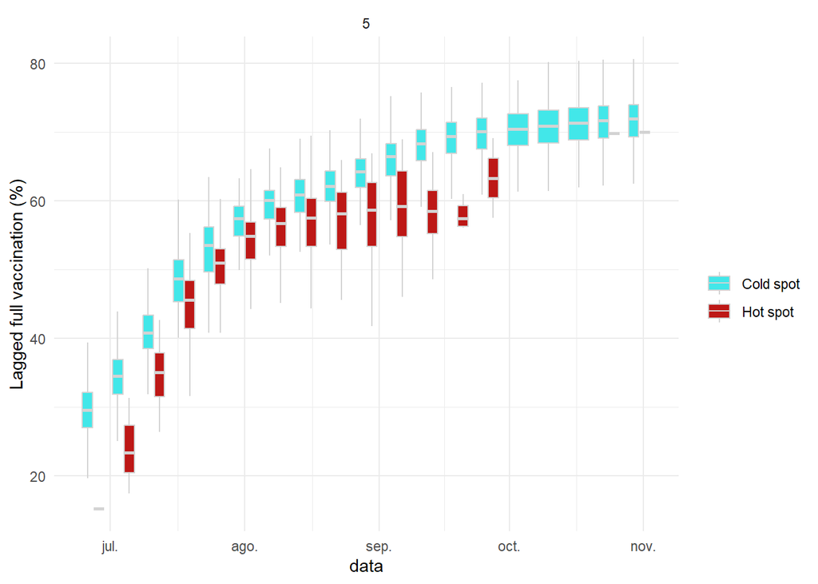

Hot spots have a lot lower vaccination percentages than cold spots. We can see how considering SIR for the whole periods in lower hospitalization incidence weeks there are almost no hot spots.

Table 32: Description of estimated DIC and WAIC for all the models

|  | Cases DIC | Cases WAIC | Hospitalization DIC | Hospitalization WAIC |
| --- | --- | --- | --- | --- |
| Raw | 44326.47 | 44495.02 | 21274.97 | 20925.62 |
| Vaccination |  |  | 21270.30 | 20940.01 |
| Vaccination + Covariates | 44320.74 | 44502.96 | 21272.04 | 20942.79 |
| Vaccination (2-week lag) | 44310.15 | 44480.08 | 21265.66 | 20927.00 |

Table 33: Estimated fixed effects and hyperparameters for each model on the cases outcome

|  | Raw | Vaccination + Covariates | Vaccination (2-week lag) |
| --- | --- | --- | --- |
| **Fixed effects** |  |  |  |
| (Intercept) | 0.31 (0.31, 0.32) | 0.31 (0.3, 0.32) | 0.87 (0.84, 0.9) |
| Urban vs Rural |  | 1.03 (0.97, 1.09) | 1.04 (0.98, 1.11) |
| Socioeconomic Index (SI) |  | 0.98 (0.95, 1.01) | 1.01 (0.99, 1.04) |
| Full vaccination (1-week lag) |  | 0.76 (0.7, 0.82) |  |
| Full vaccination (2-week lags) |  |  | 0.93 (0.86, 0.97) |
| **Random effects** |  |  |  |
| SD (idarea) | 0.22 (0.24, 0.21) | 0.2 (0.22, 0.18) | 0.21 (0.24, 0.18) |
| Phi for idarea | 0.61 (0.41, 0.76) | 0.52 (0.34, 0.74) | 0.47 (0.1, 0.77) |
| SD (idtime) | 0.46 (0.64, 0.36) | 0.48 (0.73, 0.34) | 0.06 (0.1, 0.04) |
| SD (idareatime) | 0.29 (0.3, 0.28) | 0.29 (0.3, 0.28) | 0.29 (0.3, 0.28) |

The vaccination has a protective effect of the 24%, adjusted by covariates. Considering 2-week lags, the effect decreases to 7%.

The role of the structural spatial effect decreases.

Table 34: Percentage of explained variability by the spatial, temporal and spatio-temporal patterns of every model on the cases outcome

|  | Variance Spatial (%) | Variance Temporal (%) | Variance Spatio-Temporal (%) |
| --- | --- | --- | --- |
| Raw | 14.19 | 61.66 | 24.15 |
| Vaccination + Covariates | 11.77 | 63.78 | 24.44 |
| Vaccination (2-week lag) | 30.95 | 3.39 | 65.66 |

The percentage of spatial variance slightly decreases in benefit of the temporal variance for the adjusted model of vaccination + covariates.

Table 35: Estimated fixed effects and hyperparameters for each model on the hospitalization outcome

|  | Raw | Vaccination | Vaccination + Covariates | Vaccination (2-week lag) |
| --- | --- | --- | --- | --- |
| **Fixed effects** |  |  |  |  |
| (Intercept) | 0.46 (0.44, 0.48) | 0.46 (0.44, 0.48) | 0.43 (0.4, 0.47) | 0.74 (0.69, 0.8) |
| Full vaccination (1-week lag) |  | 0.49 (0.43, 0.57) | 0.6 (0.51, 0.7) |  |
| Urban vs Rural |  |  | 1.16 (1.02, 1.32) | 1.21 (1.05, 1.38) |
| Socioeconomic Index (SI) |  |  | 1.14 (1.08, 1.21) | 1.23 (1.17, 1.3) |
| Full vaccination (2-week lags) |  |  |  | 0.97 (0.92, 1.01) |
| **Random effects** |  |  |  |  |
| SD (idarea) | 0.54 (0.61, 0.49) | 0.43 (0.47, 0.4) | 0.41 (0.46, 0.37) | 0.43 (0.48, 0.38) |
| Phi for idarea | 0.66 (0.47, 0.82) | 0.42 (0.22, 0.63) | 0.31 (0.1, 0.54) | 0.44 (0.18, 0.75) |
| SD (idtime) | 0.27 (0.43, 0.2) | 0.39 (0.55, 0.29) | 0.36 (0.57, 0.26) | 0.02 (0.04, 0.01) |
| SD (idareatime) | 0.23 (0.25, 0.21) | 0.22 (0.24, 0.21) | 0.22 (0.24, 0.21) | 0.23 (0.24, 0.21) |

Vaccination has a big protective effect of 51% that remains high when adjusted by covariates (40%). Considering 2-week lags the effect decreases to 3% at limit of significance.

The role of the structural effect decreases when adjusted.

Table 36: Percentage of explained variability by the spatial, temporal and spatio-temporal patterns of every model on the hospitalization outcome

|  | Variance Spatial (%) | Variance Temporal (%) | Variance Spatio-Temporal (%) |
| --- | --- | --- | --- |
| Raw | 68.12 | 19.85 | 12.04 |
| Vaccination | 46.75 | 40.68 | 12.57 |
| Vaccination + Covariates | 46.93 | 38.37 | 14.70 |
| Vaccination (2-week lag) | 78.19 | 0.17 | 21.64 |